# Chapter 2

Randy

7/1/2021

# Regression

## simulated dataset

### package

```r
library("tidymodels")
library("tidyverse")

library("here")
library("janitor")

library("knitr")
library("tinytex")
library("bookdown")
```

- simulated data over 28 days for one menstrual cycle
- *the outcome is prog (Progesterone)*
- *the primary explanatory variable is daystacked (cycle day)*
- ignore the other columns for now.
- progesterone is coded to constant/low-level until Day 15
- after Day15 it increases through Day 21
- decreases back to baseline at Day 28
- simulated data assumes progesterone is measured without error
- *this data seems ‘similar’ to R&W’s figure-2.6*
- two equivalent views
  - function space view
  - weight space view

## 2.1 Weight-space View

- training set $\mathcal D$
- design matrix
- target

### 2.1.1 The standard linear model (2.1)

$$f(\pmb x) = \pmb x ^{\top} \pmb w,\ y = f(\pmb x) + \epsilon,
\ \ \ \ (2.1)$$

## load data

```r
set.seed(555)

progsim_one <- here::here("data", "progsim_one.csv") %>%
  read.csv(row.names = 1) %>%
  janitor::clean_names()
# View(progsim_one)
# str(progsim_one)
```

this the data without noise, $f(x)$ in equation (2.1)

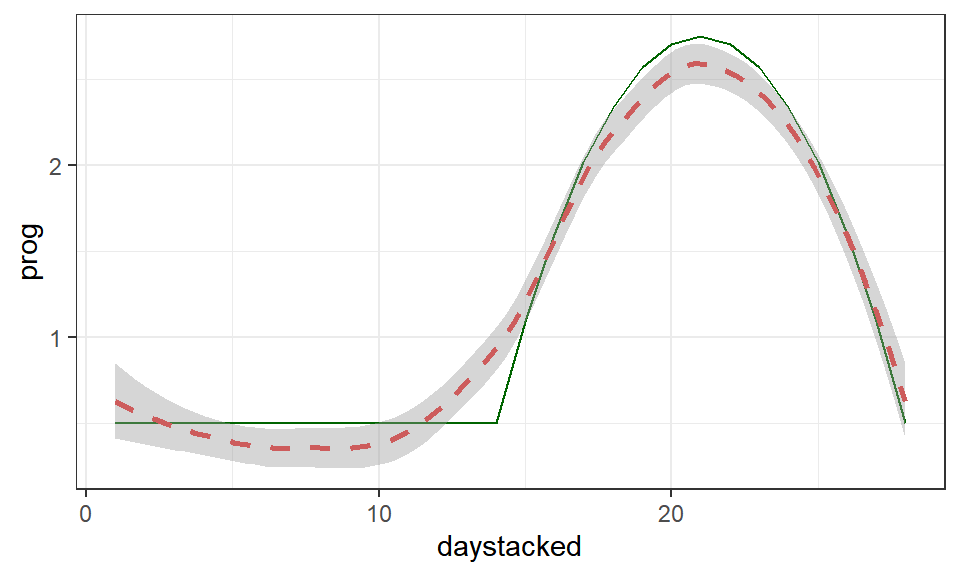

```r
plot1 <- progsim_one %>%
  ggplot(aes(daystacked, prog)) +
  geom_line(col = "darkgreen") +
  geom_smooth(col = "indianred",
              linetype = "dashed")
plot1 + theme_bw()
```

without noise the plot and the autoregression, $f(x)$ in equation (2.1)

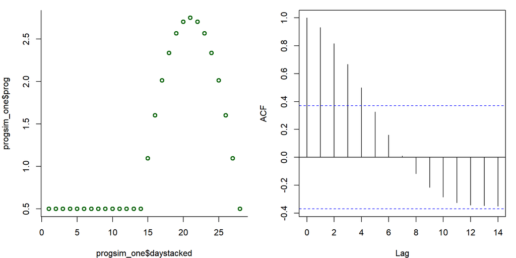

```r
op <- par(mfrow = c(1, 2),
          mar = c(4, 4, 1, 1))
plot(progsim_one$daystacked,
     progsim_one$prog,
     type = "p",
     col = "darkgreen",
     lwd = 2,
     bty = "l")
acf(progsim_one$prog)
```

```r
par(op)
```

- bias/offset

$$\epsilon \sim \mathcal N(0,\ \sigma^2_n) \ \ \ \ (2.2)$$

```r
W <- progsim_one$prog / (1:28)
sigma <- 0.1
epsilon_n <- rnorm(length(progsim_one$prog), 0, sigma)

progsim_one <- progsim_one %>%
  mutate(prog_y = prog + epsilon_n)

# View(epsilon_n)
# View(progsim_one)
```

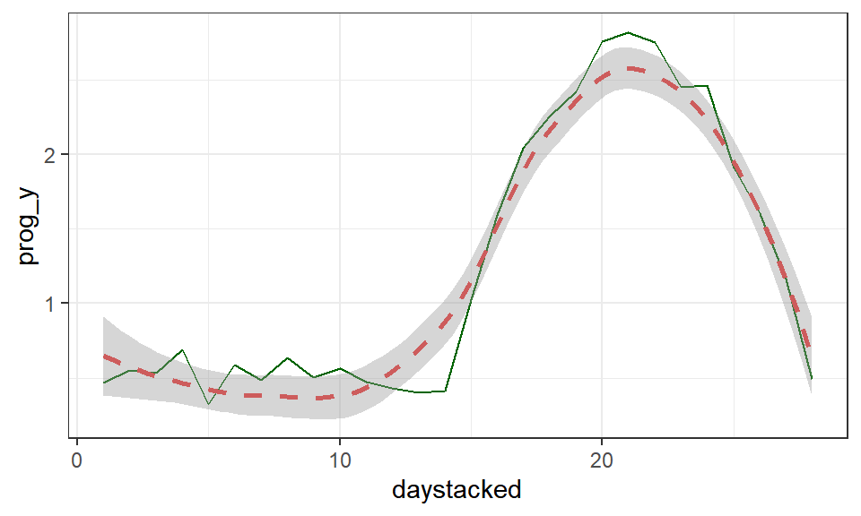

```r
plot2 <- progsim_one %>%
  ggplot(aes(daystacked, prog_y)) +
  geom_line(col = "darkgreen") +
  geom_smooth(col = "indianred",
              linetype = "dashed")
plot2 + theme_bw()
```

with noise the plot and the autoregression, $y$ in equation (2.1)

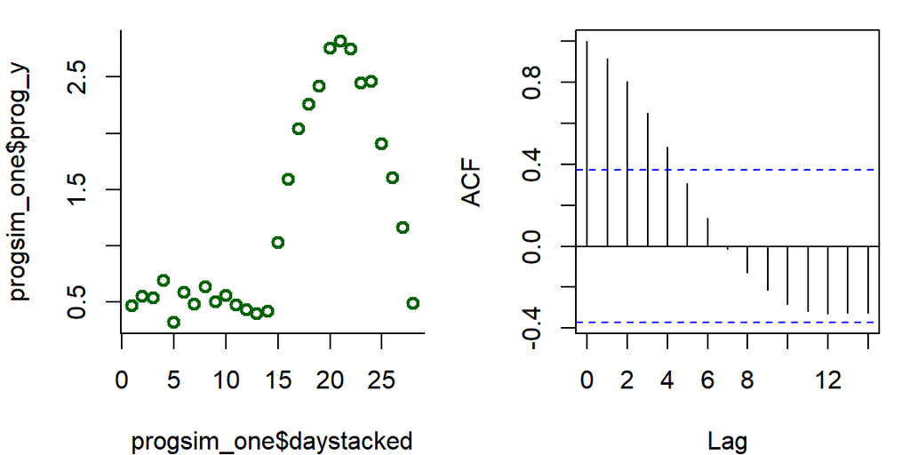

```r
op <- par(mfrow = c(1, 2),
          mar = c(4, 4, 1, 1))
plot(progsim_one$daystacked,
     progsim_one$prog_y,
     type = "p",
     col = "darkgreen",
     lwd = 2,
     bty = "l")
acf(progsim_one$prog_y)
```

```r
par(op)
```

- likelihood
- probability density

$$p(\pmb y|\pmb X,\ \pmb w) = \prod_{i=1} ^n p(y_i|\pmb x_i,\ \pmb w)
= \prod{\frac{1}{\sqrt{2\pi}\sigma_n}exp\Big(-\frac {(y_i-\pmb x_i^{\top} \pmb w)^2}
{2\sigma^2_n}\Big)} \\
= \frac{1} {(2\pi\sigma^2_n)^{n/2}} exp \Big(-\frac{1} {2\sigma_n^2}
|\pmb y- \pmb X^{\top} \pmb w|^2 \Big)
= \mathcal N(\pmb X^{\top} \pmb w,\ \sigma^2_n \pmb I),
\ \ \ \ (2.3)$$

- prior

$$\pmb w \sim \mathcal N(\pmb 0,\ \Sigma_p)
\ \ \ \ (2.4)$$

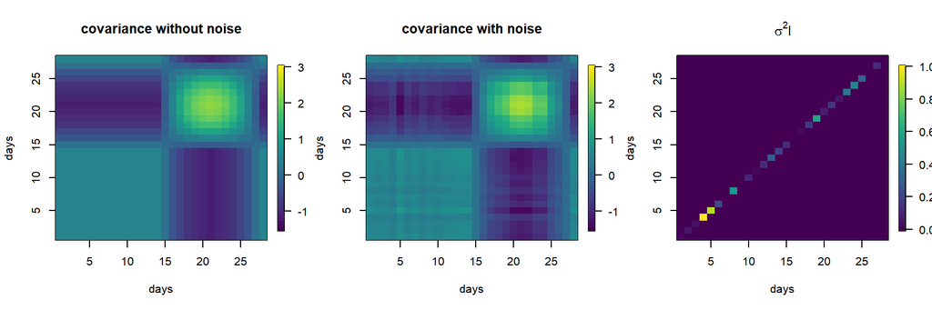

```r
## time scale
days <- progsim_one$daystacked

## without noise
prog <- progsim_one$prog
prog_mu <- mean(progsim_one$prog)
prog_cov <- (prog - prog_mu) %*% t(prog - prog_mu)
prog_cor <- cov2cor(prog_cov)
prog_eigen <- eigen(prog_cov)

## with noise
progy <- progsim_one$prog_y
progy_mu <- mean(progsim_one$prog_y)
progy_cov <- (progy - progy_mu) %*% t(progy - progy_mu)
progy_cor <- cov2cor(progy_cov)
progy_eigen <- eigen(progy_cov)

error_cov <- diag(28, 28) * (epsilon_n)^2

op <- par(mfrow = c(1, 3))
fields::image.plot(days, days,
                   prog_cov,
                   zlim = c(-1.5, 3),
                   col = viridis::viridis(50),
                   main = "covariance without noise")

fields::image.plot(days, days,
                   progy_cov,
                   zlim = c(-1.5, 3),
                   col = viridis::viridis(50),
                   main = "covariance with noise")

fields::image.plot(days, days,
                   error_cov,
                   col = viridis::viridis(50),
                   main = expression(paste(sigma^2, "I")))
```

```r
par(op)

## error for N-PSD matrix why? -------------------------------------------------
# alpha <- solve(k_se)
# alpha <- solve(prog_cov)
# L <- chol(prog_cov)
# L <- chol(k_se)

## cholesky & left division does not work --------------------------------------
# t(solve(t(prog_cov), t(k_se0)))
```

### kernels

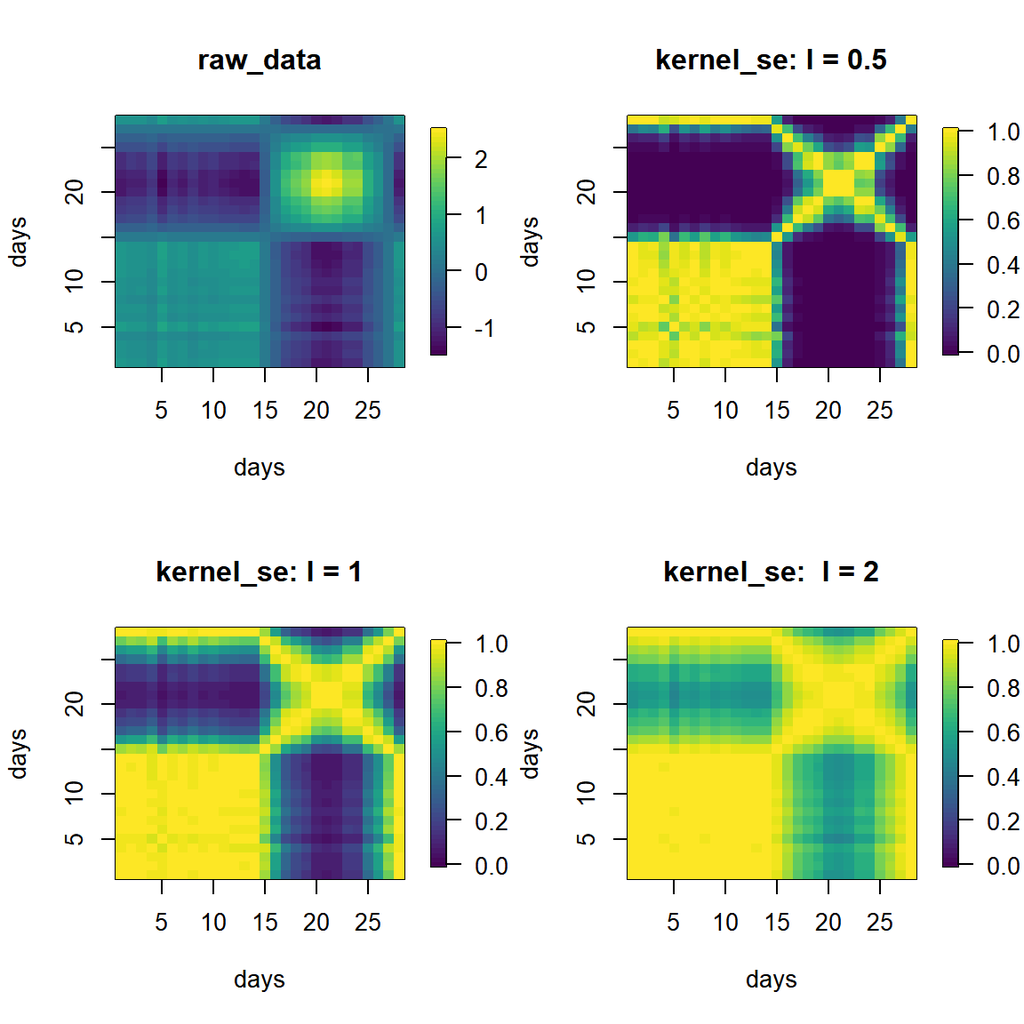

```r
# seq_along(prog)
k_se0 <- matrix(nrow = 28, ncol = 28)
k_se1 <- matrix(nrow = 28, ncol = 28)
k_se2 <- matrix(nrow = 28, ncol = 28)

## kernel se for characteristic length scale 1
for (i in seq_along(progy)) {
  for (j in seq_along(progy)) {
    k_se0[i, j] <-
      exp(-0.5 * (progy[i] - progy[j])^2)
  }
}
## kernel se for characteristic length scale 0.5
for (i in seq_along(progy)) {
  for (j in seq_along(progy)) {
    k_se1[i, j] <-
      exp(-0.5 * ((progy[i] - progy[j]) / 0.5)^2)
  }
}
## kernel se for characteristic length scale 2
for (i in seq_along(progy)) {
  for (j in seq_along(progy)) {
    k_se2[i, j] <-
      exp(-0.5 * ((progy[i] - progy[j]) / 2)^2)
  }
}


## heatmap plots
op <- par(mfrow = c(2, 2))
fields::image.plot(days, days,
                   progy_cov,
                   col = viridis::viridis(50),
                   main = "raw_data")
## kernel se for characteristic length scale 0.5
fields::image.plot(days, days,
                   k_se1,
                   zlim = c(0, 1),
                   col = viridis::viridis(50),
                   main = "kernel_se: l = 0.5" )
## kernel se for characteristic length scale 1
fields::image.plot(days, days,
                   k_se0,
                   zlim = c(0, 1),
                   col = viridis::viridis(50),
                   main = "kernel_se: l = 1")
## kernel se for characteristic length scale 2
fields::image.plot(days, days,
                   k_se2,
                   zlim = c(0, 1),
                   col = viridis::viridis(50),
                   main = "kernel_se:  l = 2")
```

```r
par(op)
```

- posterior
- marginal likelihood

$$p(w|y,\ X) = \frac {p(y|X,\ w)p(w)} {p(y|X)}
\ \ \ \ (2.5)\\
p(y|X) = \int p(y|X,\ w)p(w)dw
\ \ \ \ (2.6)$$

$$p(w|X, y) \propto exp \Big( -\frac{1} {2\sigma^2_n} (y - X^{\top} w)^{\top}(y - X^{\top} w) \Big)
exp \Big( -\frac{1} {2} (w^{\top}\Sigma_p ^{-1} w) \Big) \\
\propto exp \Big( -\frac{1} {2} (w - \bar w)^{\top} (\frac{1} {\sigma_n^2}XX^{\top} + \Sigma^{-1}_p) (w - \bar w) \Big) \ \ \ \ (2.7)\\
\bar w =\sigma^{-2}_n ({\sigma_n^ {-2}} XX^{\top} + \Sigma^{-1}_p)^{-1}Xy$$

**sidenotes** in another words, to maximized the likelihood function is to minimized the contrast. for smoothing splines, the penalized residual sum of squares, we get the equation (2.7b&c)

$\sigma_n$ is a value 0.1

$$\hat w = ( XX^{\top} + {\sigma_n^ {2}}\Sigma^{-1}_p)^{-1}Xy\ \ \ \ (2.7a)\\
PRSS(f,\ \lambda) = \sum^N_{i=1}(y_i - f(x_i))^2+\lambda\int f''(t)^2dt\ \ \ \ (2.7b)\\
PRSS(\theta,\ \lambda) = (y- \Phi\theta)^{\top}(y-\Phi\theta)+\lambda\theta^{\top}\Omega_\Phi\theta \ \ \ (2.7c)\\
\hat \theta = (\Phi^{\top}\Phi+\lambda\Omega_\Phi)^{-1}\Phi^{\top}y\ \ \ \ (2.7d)\\
\hat f = \Phi(\Phi^{\top}\Phi+\lambda\Omega_\Phi)^{-1}\Phi^{\top}y = S_\lambda y\ \ \ \ (2.7e)\\
given,\ f(x) = \sum^N_{j=1}\phi_j(x)\theta_j\\
\{\Phi\}_{ij}=\phi_j(x_i)\\
\{\Omega_\Phi\}_{ij}=\int \Phi''_j(t)\Phi''_k(t)dt$$

The posterior is also a Gaussian

$$p(w|X,\ y)\sim \mathcal N(\bar w = \frac{1} {\sigma^2_n}A^{-1}Xy,\ A^{-1})\\
A = \sigma^{-2}XX^{\top} + \Sigma_p^{-1}
\ \ \ \ (2.8)$$

- MAP estimate (maximum a posteriori)
- ridge regression
  - penalized maximum likelihood estimate of the weights
  - penalty term $\frac 1 2 w^{\top}\Sigma_p^{-1}w$
- predictive distribution

$$A = \sigma^{-2}XX^{\top} + \Sigma_p^{-1}\\
f_* \stackrel {\Delta}{=} f(x_*) \\
p(f_*|x_*,\ X,\ y) = \int p(f_*|x_*,\ w)p(w|X,\ y)dw\\
\mathcal N(\frac{1}{\sigma^2_n}x_*^{\top}A^{-1}Xy,\ x_*^{\top}A^{-1}x_*)
\ \ \ \ (2.9)$$

### 2.1.2 Projection of Inputs into Feature Space

- feature space
- polynomial regression
- linear in the parameters

$$f(x) = \phi (x)^{\top}w
\ \ \ \ (2.10)\\
w_0 + w_1x +w_2x^2\\
\pmb \Phi \pmb w\\
\phi =(1, x, x^2)\\
w = (w_0, w_1, w_2)$$

**notes** for example, additive models, we have treatment, and racial factors

$$f(time) = f_0(time) + f_{treatment}(time) + f_{race}(time)\\
= \phi_0(time) + \phi_{treatment}(time)\theta_{treatment} + \phi_{treatment}(time)\theta_{race}\\
= \sum_{i=0}^p\phi_i\theta_i = \pmb{\Phi}(time)\pmb \theta$$

potentially $\theta$ can also be a function of time? then tensor

- explicit feature space formulation

$$\Phi = \Phi(X)\\
A = \sigma_n^{-2}\Phi\Phi^{\top} + \Sigma_{p}^{-1}\\
f_*|x_*,\ X,\ y\
\sim
\mathcal N(\frac {1} {\sigma^2_n} \phi(x_*)^{\top} A^{−1} \Phi y,\
\phi(x_*)^{\top}A^{−1}\phi(x_*))
\ \ \ \ (2.11)$$

- alternative formulation

$$f_*|x_*,\ X,\ y\ \sim N (\phi^{\top}_* \Sigma_p \Phi(K + \sigma_n^2I)^{−1}y,\
\phi_*^{\top} \Sigma_p \phi_* − \phi_*^{\top} \Sigma_p \Phi(K + \sigma_n^2I)^{−1} \Phi^{\top}\Sigma_p\phi_*)
\ \ \ \ (2.12)\\
\phi(x_*) = \phi_*,\ \ K = \Phi^{\top} \Sigma_p\Phi,\ \\
\sigma_n^{-2}\Phi(K + \sigma_n^2I) = \sigma_n^{-2}\Phi(\Phi^{\top} \Sigma_p\Phi +
\sigma_n^2I) = A\Sigma_p\Phi\\
\sigma^{-2}_nA^{-1}\Phi = \Sigma_p\Phi(K+\sigma^2_nI)^{-1}$$

- covariance function or kernel
- SVD singular value decomposition
- inner product and dot product
- kernel trick

Inversion lemma

$$(Z + UWV^{\top})^{-1} = Z^{-1}-Z^{-1}U(W^{-1}+V^{\top}Z^{-1}U)^{-1}V^{\top}Z^{-1}
\ \ \ \ (A.9)$$

## 2.2 Function-space View

- **Definition 2.1 A Gaussian process is a collection of random variables, any Gaussian process finite number of which have a joint Gaussian distribution.**
- mean function
- covariance function

$$m(x) = \mathbb E[f(x)],\\
k(x,\ x') = \mathbb E[(f(x) − m(x))(f(x') − m(x'))]
\ \ \ \ (2.13)$$

- index set
- input domain

$$f(x) \sim \mathcal {GP} (m(x), k(x, x')) \ \ \ (2.14)\\
f(x) = \phi (x)^{\top}w,\ \ f(x) \sim \mathcal N(\Phi w,\ \Phi\Sigma_p\Phi) \ \ \ \ (2.10)\\
time \ \ \ \ 1,2,3,4,
w: w_1 w_2$$

- consistency
- marginalization property

$$f(x) = \phi(x)^{\top} w\\
w \sim \mathcal N(\pmb 0, \Sigma_p)\\
\mathbb E[f(x)] = \phi(x)^{\top} \mathbb E[w] = 0,\\
\mathbb E[f(x)f(x')] = \phi(x)^{\top}\mathbb E[ww^{\top}]\phi(x') =
\phi(x)^{\top}\Sigma_p\phi(x')
\ \ \ \ (2.15)$$

- **Bayesian linear model is a Gaussian process**
- Squared exponential SE covariance function

$$cov \big(f(x_p),\ f(x_q)\big) =
k(x_p,\ x_q) =
exp \Big(− \frac 1 2 |x_p − x_q|^2 \Big)
\ \ \ \ (2.16)$$

- basis functions

$$f_* \sim \mathcal N\big(\pmb 0,\ K(X_*,\ X_*)\big)
\ \ \ \ (2.17)$$

- smoothness
- characteristic length scale

### Prediction with Noise-free Observation

$$\begin{bmatrix}
f\\
f_*
\end{bmatrix}
\sim
\mathcal N
\begin{pmatrix}
\pmb 0,\
\begin{bmatrix}
K(X,\ X)\ \ \ \ \ K(X,\ X_*)\\
\ \ K(X_*,\ X)\ \ \ \ K(X_*,\ X_*)
\end{bmatrix}
\end{pmatrix}
\ \ \ \ (2.18)$$

- joint prior

```r
get_se_Sigma <- function(X1, X2, l = 1) {
  Sigma <- matrix(rep(0, length(X1) * length(X2)),
                  nrow = length(X1))

  for (i in 1:nrow(Sigma)) {
    for (j in 1:ncol(Sigma)) {
      Sigma[i, j] <- exp(-0.5 * (abs(X1[i] - X2[j]) / l)^2)
    }
  }
  return(Sigma)
}
```

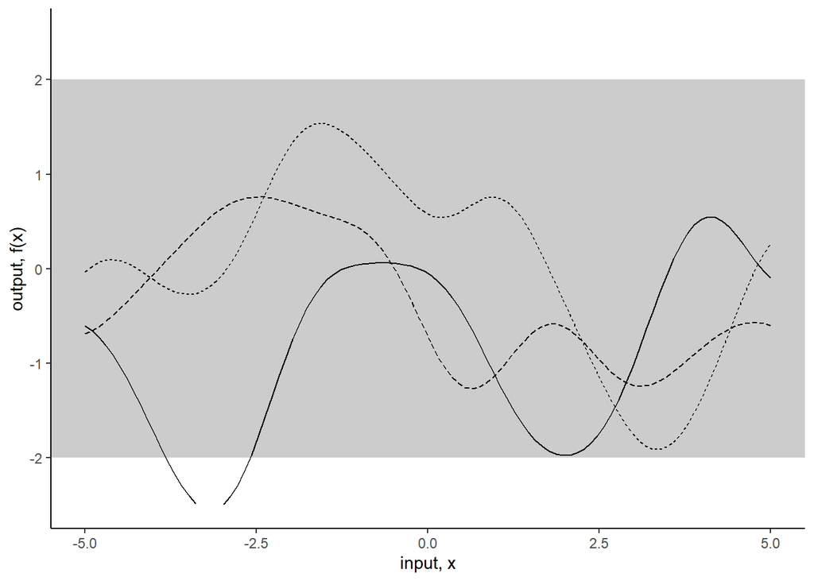

```r
set.seed(55555)

x_star <- seq(-5, 5, len = 100)
## covariance matrix
sigma <- get_se_Sigma(x_star, x_star)
## functions from the process
n_sample <- 3
values <- matrix(rep(0, length(x_star) * n_sample),
                 ncol = n_sample)

for (i in 1:n_sample) {
  values[, i] <-
    MASS::mvrnorm(1, rep(0, length(x_star)), sigma)
}

values <- cbind(x = x_star,
                as.data.frame(values))
values <- reshape2::melt(values, id = "x")

# Plot the result
fig2_2a <-
  ggplot(values,
         aes(x = x, y = value)) +
  geom_rect(xmin = -Inf,
            xmax = Inf,
            ymin = -2,
            ymax = 2,
            fill = "grey80") +
  geom_line(aes(group = variable,
                linetype = variable)) +
  scale_y_continuous(lim = c(-2.5, 2.5),
                     name = "output, f(x)") +
  xlab("input, x") +
  theme(legend.position = "none")

fig2_2a + theme_classic() + theme(legend.position = "none")
```

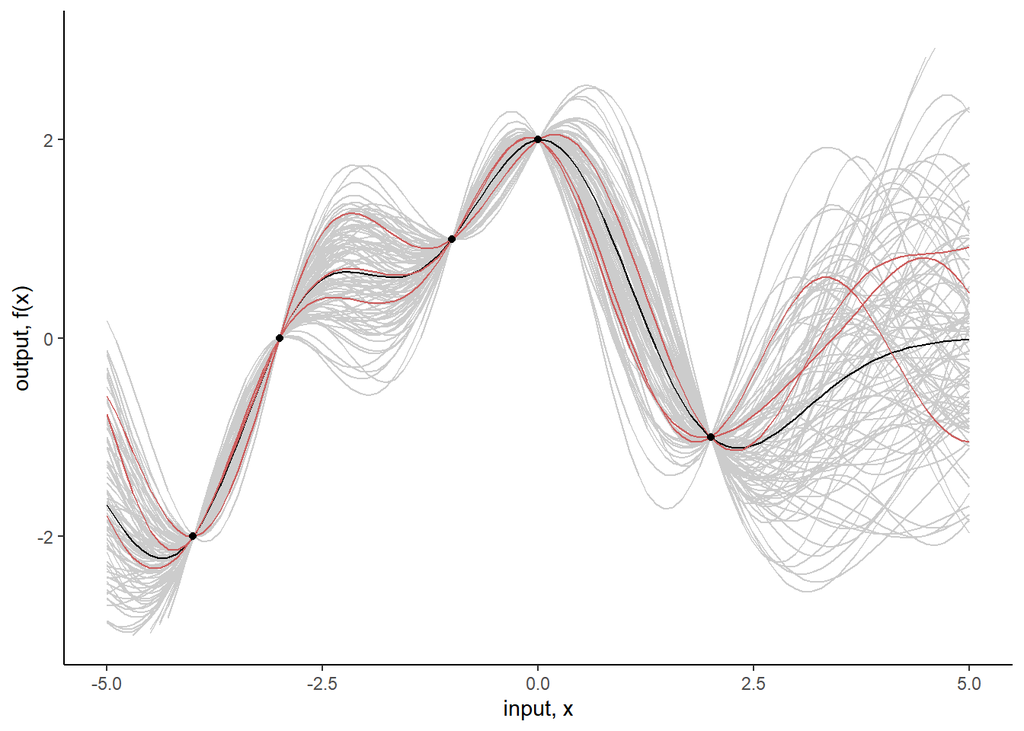

```r
f <- data.frame(x = c(-4, -3, -1, 0, 2),
                y = c(-2, 0, 1, 2, -1))

x <- f$x
l <- 1
# l <- 2

k_xx <- get_se_Sigma(x, x, l)
k_xxs <- get_se_Sigma(x, x_star, l)
k_xsx <- get_se_Sigma(x_star, x, l)
k_xsxs <- get_se_Sigma(x_star, x_star, l)

## equation (2.19)
f_star_bar <- k_xsx %*% solve(k_xx) %*% f$y
cov_f_star <- k_xsxs - k_xsx %*% solve(k_xx) %*% k_xxs

## plot more samples
## with samples explicitly here.

n_samples <- 100
values <- matrix(rep(0, length(x_star) * n_samples),
                 ncol = n_samples)

for (i in 1:n_samples) {
  values[, i] <- MASS::mvrnorm(1, f_star_bar, cov_f_star)
}

values <- cbind(x = x_star, as.data.frame(values))
values <- reshape2::melt(values, id = "x")
View(values)

selected <- values %>%
  filter(variable %in% c("V25", "V95", "V5"))

fit <- cbind(f_star_bar, x_star) %>%
  data.frame()

# Plot the results including the mean function
# and constraining data points
fig2_2b <- ggplot() +
  geom_line(data = values,
            aes(x = x,
                y = value,
                group = variable),
            colour = "grey80") +
  geom_line(data = fit,
            aes(x = x_star,
                y = f_star_bar)) +
  geom_line(data = selected,
            aes(x = x,
                y = value,
                group = variable),
            color = "indianred") +
  geom_point(data = f,
             aes(x = x,
                 y = y)) +
  scale_y_continuous(lim = c(-3, 3),
                     name = "output, f(x)") +
  xlab("input, x")

fig2_2b + theme_classic()
```

this figure tells us that when there is no noise for observations, then the posterior distribution of at the observed points have the least variability (the posterior’s variance is just zero, because we know that the the prediction will be exactly the same as the observed as we talked about). The further away from the observed points the larger of the variance: so the the largest variability showed up at the two edges, and the middle of the two observed points also have large variability.

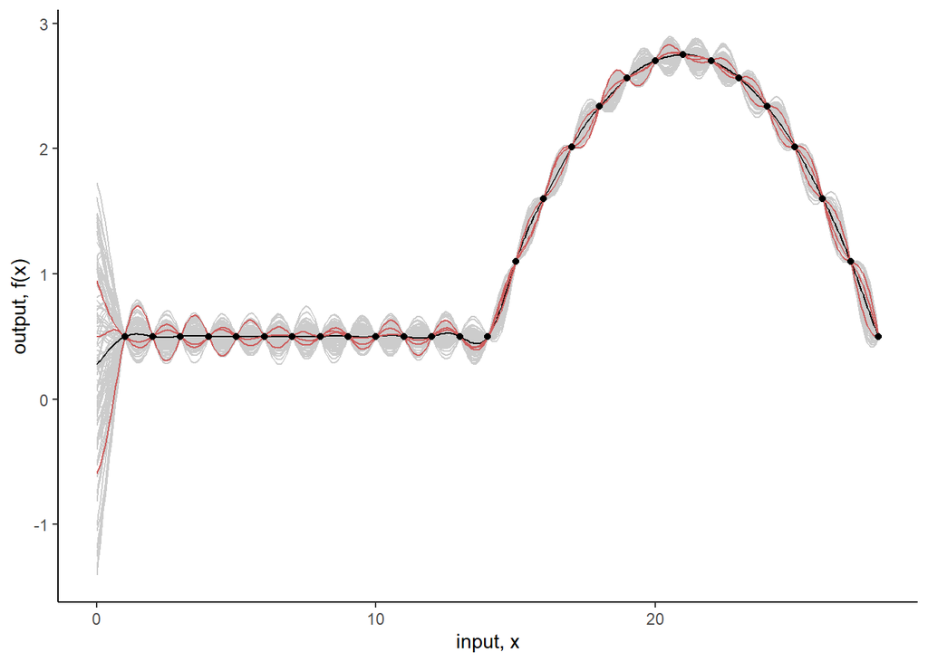

```r
f <- data.frame(x = progsim_one$daystacked,
                y = progsim_one$prog)
x_star <- seq(0, 28, len = 500)

x <- f$x
k_xx <- get_se_Sigma(x, x, l)
k_xxs <- get_se_Sigma(x, x_star, l)
k_xsx <- get_se_Sigma(x_star, x, l)
k_xsxs <- get_se_Sigma(x_star, x_star, l)

## equation (2.19)
f_star_bar <- k_xsx %*% solve(k_xx) %*% f$y
cov_f_star <- k_xsxs - k_xsx %*% solve(k_xx) %*% k_xxs

n_samples <- 100
values <- matrix(rep(0, length(x_star) * n_samples),
                 ncol = n_samples)

for (i in 1:n_samples) {
  values[, i] <- MASS::mvrnorm(1, f_star_bar, cov_f_star)
}

values <- cbind(x = x_star, as.data.frame(values))
values <- reshape2::melt(values, id = "x")

selected <- values %>%
  filter(variable %in% c("V25", "V95", "V5"))

fit <- cbind(f_star_bar, x_star) %>%
  data.frame()

fig_sim <- ggplot() +
  geom_line(data = values,
            aes(x = x,
                y = value,
                group = variable),
            colour = "grey80") +
  geom_line(data = fit,
            aes(x = x_star,
                y = f_star_bar)) +
  geom_line(data = selected,
            aes(x = x,
                y = value,
                group = variable),
            color = "indianred") +
  geom_point(data = f,
             aes(x = x,
                 y = y)) +
  scale_y_continuous(name = "output, f(x)") +
  xlab("input, x")

fig_sim + theme_classic()
```

$$f_*|X_*,\ X,\ f\ \sim \mathcal N \Big(K(X_*,\ X)K(X,\ X)^{−1}f,\ \ \
K(X_*,\ X_*)−K(X_*,\ X)K(X,\ X)^{−1} K(X,\ X_*) \Big)
\ \ \ \ (2.19)$$

- graphical rejection
- noise free predictive distribution

### Prediction using Noisy Observation

$$cov(y_p,\ y_q) = k(x_p,\ x_q) + \sigma_n^2\delta_{pq}\\
cov(\pmb y) = K(X,\ X) + \sigma_n^2I
\ \ \ \ (2.20)$$

$$\begin{bmatrix}
y\\
f_*
\end{bmatrix}
\sim
\mathcal N
\begin{pmatrix}
\pmb 0,\
\begin{bmatrix}
K(X,\ X)+\sigma^2_nI\ \ \ \ \ K(X,\ X_*)\\
\ \ \ \ \ K(X_*,\ X)\ \ \ \ \ \ \ \ \ \ K(X_*,\ X_*)
\end{bmatrix}
\end{pmatrix}
\ \ \ \ (2.21)$$

- predictive distribution

$$f_*|X,\ y,\ X_*\ \sim \mathcal N \big(\bar {f_*},\ cov(f_*)\big)\ \ \ \ (2.22)\\
\bar {f_*} \stackrel {\Delta} {=} \mathbb E[f_*|X,\ y,\ X_*] =
K(X_*,\ X)[K(X,\ X) + \sigma_n^2I]^{−1}y\ \ \ \ (2.23)\\
cov(f_*) = K(X_*,\ X_*) − K(X_*,\ X)\big[K(X,\ X) + \sigma_n^2I\big]^{-1}K(X,\ X_*)\ \ \ \ (2.24)$$

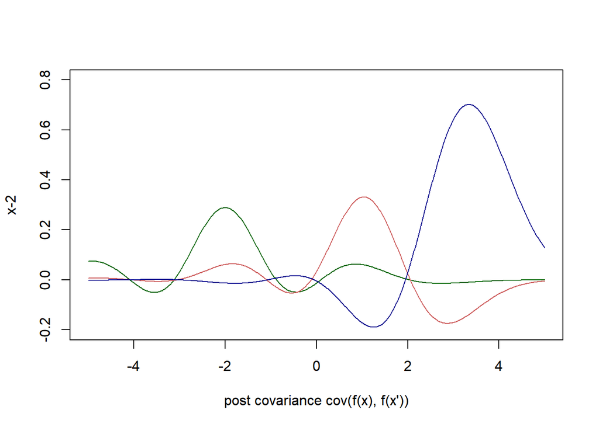

```r
x_star <- seq(-5, 5, len = 500)
## covariance matrix
sigma <- get_se_Sigma(x_star, x_star)

f <- data.frame(x = c(-4, -3, -1, 0, 2),
                y = c(-2, 0, 1, 2, -1))
x <- f$x
k_xx <- get_se_Sigma(x, x, l)
k_xxs <- get_se_Sigma(x, x_star, l)
k_xsx <- get_se_Sigma(x_star, x, l)
k_xsxs <- get_se_Sigma(x_star, x_star, l)

## equation (2.19)
f_star_bar <- k_xsx %*% solve(k_xx + diag(5, 5) * (0.1)^2) %*% f$y
cov_f_star <- k_xsxs - k_xsx %*% solve(k_xx + diag(5, 5) * (0.1)^2) %*% k_xxs

# View(cov_f_star[, 400])
`x-2` <- cov_f_star[, 150]
x1 <- cov_f_star[, 300]
x3 <- cov_f_star[, 400]

plot(x_star, `x-2`,
     type = "l",
     ylim = c(-0.2, 0.8),
     col = "darkgreen",
     xlab ="post covariance cov(f(x), f(x'))")
lines(x_star, x1,
      col = "indianred")
lines(x_star, x3,
      col = "darkblue")
```

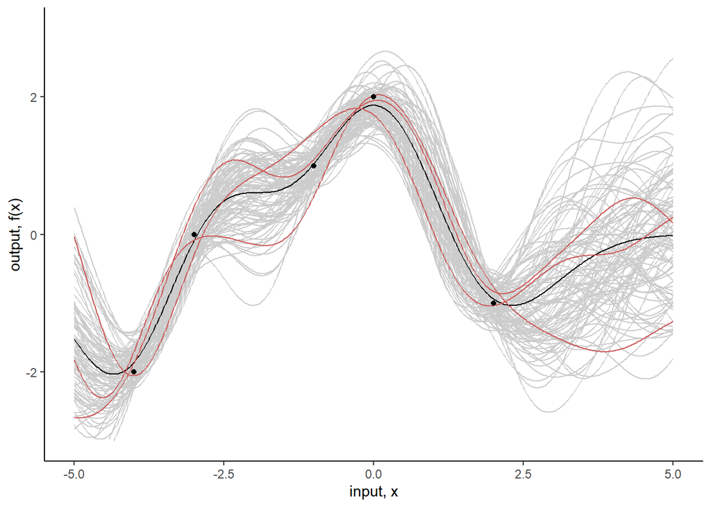

```r
## plot more samples
## with samples explicitly here.

n_samples <- 100
values <- matrix(rep(0, length(x_star) * n_samples),
                 ncol = n_samples)

for (i in 1:n_samples) {
  values[, i] <- MASS::mvrnorm(1, f_star_bar, cov_f_star)
}


values <- cbind(x = x_star, as.data.frame(values))
values <- reshape2::melt(values, id = "x")

selected <- values %>%
  filter(variable %in% c("V25", "V95", "V5"))

fit <- cbind(f_star_bar, x_star) %>%
  data.frame()

fig2_4a <- ggplot() +
  geom_line(data = values,
            aes(x = x,
                y = value,
                group = variable),
            colour = "grey80") +
  geom_line(data = fit,
            aes(x = x_star,
                y = f_star_bar)) +
  geom_line(data = selected,
            aes(x = x,
                y = value,
                group = variable),
            color = "indianred") +
  geom_point(data = f,
             aes(x = x,
                 y = y)) +
  scale_y_continuous(lim = c(-3, 3), name = "output, f(x)") +
  xlab("input, x")

fig2_4a + theme_classic()
```

there will be variability at the given observed points, but still roughly those are the points we are mostly sure about so there is less variability (narrow confidence bands if we plot them, ); also the further away from the observed data, the less sure of the predictions (the larger variance for the posterior).

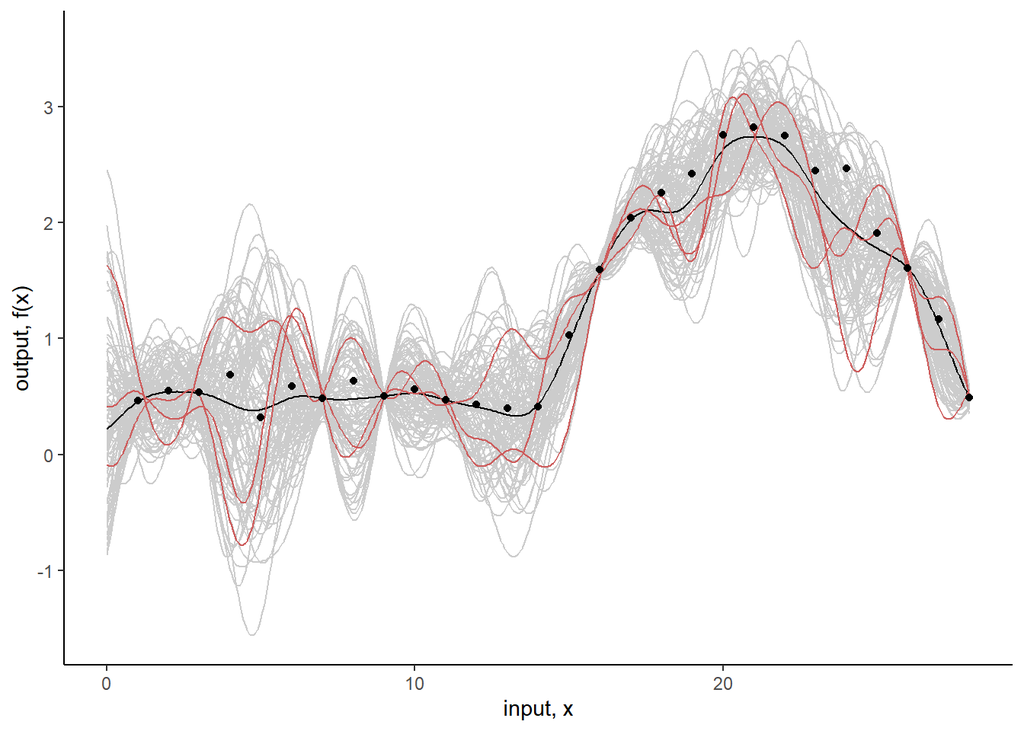

```r
f <- data.frame(x = progsim_one$daystacked,
                y = progsim_one$prog_y)

x_star <- seq(0, 28, len = 500)

x <- f$x
k_xx <- get_se_Sigma(x, x, l)
k_xxs <- get_se_Sigma(x, x_star, l)
k_xsx <- get_se_Sigma(x_star, x, l)
k_xsxs <- get_se_Sigma(x_star, x_star, l)
# View(k_xxs)
## equation (2.23)
f_star_bar <- k_xsx %*% solve(k_xx + diag(28, 28) * (epsilon_n)^2) %*% f$y
## equation (2.24)
cov_f_star <- k_xsxs - k_xsx %*% solve(k_xx + diag(28, 28) * (epsilon_n)^2) %*% k_xxs

n_samples <- 100
values <- matrix(rep(0, length(x_star) * n_samples),
                 ncol = n_samples)

for (i in 1:n_samples) {
  values[, i] <- MASS::mvrnorm(1, f_star_bar, cov_f_star)
}

values <- cbind(x = x_star, as.data.frame(values))
values <- reshape2::melt(values, id = "x")

selected <- values %>%
  filter(variable %in% c("V25", "V95", "V5"))

fit <- cbind(f_star_bar, x_star) %>%
  data.frame()

# plot the mean function
# and constraining data points
fig_sim_e <- ggplot() +
  geom_line(data = values,
            aes(x = x,
                y = value,
                group = variable),
            colour = "grey80") +
  geom_line(data = fit,
            aes(x = x_star,
                y = f_star_bar)) +
  geom_line(data = selected,
            aes(x = x,
                y = value,
                group = variable),
            color = "indianred") +
  geom_point(data = f,
             aes(x = x,
                 y = y)) +
  scale_y_continuous(name = "output, f(x)") +
  xlab("input, x")

fig_sim_e + theme_classic()
```

The individual observation does not guarantee the least variability for the prediction. the predicted points at the original observed points mostly consistent with the trend have the least variance.

**my notes for this part: the prediction above are based on the posterior distribution for the entire time-range. if we are interested on the prediction on a given time point or a subset of the time range, we can simply find the specific covariance for the subset and use exactly the same methods. I think it is due to the conditional independent feature of the Gaussian Process. those specific subset of the time range will still be a Gaussian Process.**

- compact notation $K(C,\ D) = \Phi(C)^{\top}\Sigma_p\Phi(D)$, where $C$, $D$ stand for either $X$ or $X_*$

$$K = K(X,\ X);\ \ K_* = K(X,\ X_*);\ \ k(x_*) = k_*\\
\bar {f_*} = k_*^{\top} (K + \sigma_n^2I)^{−1}y, \ \ \ \ (2.25)\\
\mathbb V[f_*] = k(x_*,\ x_*) − k^{\top}_* (K + \sigma_n^2I)^{−1}k_*
\ \ \ \ (2.26)$$

- linear predictor

$$\bar f(x_*) = \sum^n_{i=1}\alpha_ik(x_i,\ x_*)
\ \ \ \ (2.27) \\
\alpha = (K + \sigma^2_nI)^{-1}y$$

- representation theorem
- noisy predictions
- joint predictions
- posterior process
- marginal likelihood

### Algorithm 2.1: Predictions and log marginal likelihood for Gaussian process regression.

*Input*: $X$(inputs), $y$(targets), $k$(covariance function), $\sigma^2_n$ (noise level), $x_*$(test input)  
*2*: $L = cholesky(K + \sigma_n^2I)$ $\alpha = L^{\top}\(L\y)$  
*4*: $\bar{f_*} = k^{\top}_*\alpha$  
$v = L\k_*$  
*6*: $\mathbb V[f_*] = k(x_*, x_*) − v^{\top}v$  
$log\ p(y|X) = -\frac{1} {2} y^{\top}\alpha − \sum_i log\ L_{ii} − \frac{n}{2} log\ 2\pi$  
*8*: **return**: $\bar {f_*}$(mean), $\mathbb V[f_*]$(variance), $log\ p(y|X)$(log marginal likelihood)

```r
#' @description the cholesky decomposition from a online resource
                # http://rosettacode.org/wiki/Cholesky_decomposition#C
                # https://stackoverflow.com/questions/35026560/r-chol-and-positive-semi-definite-matrix
#' @para A the squared matrix
#' @output L the cholesky decompose;
           # if the matrix is not positive semidefinite the value will be NA
#' @example see below the function

cholesky_matrix <- function(A){

    L <- matrix(0, nrow=nrow(A), ncol=ncol(A))
    colnames(L) <- colnames(A)
    rownames(L) <- rownames(A)

    m <- ncol(L)
    for(i in 1:m){
        for(j in 1:i){
            s <- 0
            if(j > 1){
                for(k in 1:(j-1)){
                    s <- s + L[i, k] * L[j, k]
                }
            }
            if(i == j){
                L[i, j] <- sqrt(A[i, i] - s)
            } else {
                L[i, j] <- (1 / L[j, j]) * (A[i, j] - s)
            }
        }
    }
    return(L)
}
```

$$p(y|X) = \int p(y|f,\ X)p(f|X) df
\ \ \ \ (2.28)$$

$$log\ p(f|X) = −\frac 1 2f^{\top} K^{−1} f − \frac 1 2 log\ |K| − \frac n 2 log\ 2\pi
\ \ \ \ (2.29)\\
y|f\ \sim N (f, \sigma_n^2I)$$

$$log\ p(y|X) = − \frac 1 2 y^{\top} (K + \sigma_n^2I)^{−1} y − \frac 1 2 log\ |K + \sigma_n^2I| − \frac n 2 log\ 2\pi
\ \ \ \ (2.30)\\
y \sim N (\pmb 0,\ K + \sigma_n^2I)$$

A practical implementation of Gaussian process regression (GPR) is shown in *Algorithm 2.1*. The algorithm uses Cholesky decomposition, instead of directly inverting the matrix, since it is faster and numerically more stable, see *section A.4*. The algorithm returns the predictive mean and variance for noise free test data—to compute the predictive distribution for noisy test data $y_*$, simply add the noise variance $\sigma_n^2$ to the predictive $\mathbb V[f_*]$.